# GA4 BigQuery Analysis with Arrow & DuckDB

- Show All Code
- Hide All Code
- View Source

Demonstration of Efficient large-scale analytics in R using Positron

Author

Jae Jung

Published

March 13, 2026

# Setup

## Install & Load Packages

````markdown
```{r}
#| label: install-packages
#| eval: false

# Run once to install required packages
install.packages(c(
  "bigrquery", # BigQuery connector
  "DBI", # Database Interface
  "dplyr", # Data manipulation
  "arrow", # Apache Arrow (columnar, efficient)
  "duckdb", # In-process OLAP SQL engine
  "ggplot2", # Plotting
  "lubridate", # Date handling
  "scales", # Axis formatting
  "glue" # String interpolation
))
```
````

````markdown
```{r}
#| label: load-packages

library(bigrquery)
library(DBI)
library(dplyr)
library(arrow)
library(duckdb)
library(tidyverse)
```
````

# 1. Connect to BigQuery

GA4 exports data to BigQuery in sharded daily tables named `events_YYYYMMDD`. The public dataset `bigquery-public-data.ga4_obfuscated_sample_ecommerce` is a great sandbox — no credentials required beyond a GCP project.

````markdown
```{r}
#| label: bigquery-connection

# ── Configuration ────────────────────────────────────────────────────────────
GCP_PROJECT <- "ga4-bigquery-cppmsdm" # <-- change this
BQ_PROJECT <- "bigquery-public-data"
BQ_DATASET <- "ga4_obfuscated_sample_ecommerce"

# Authenticate (opens browser on first run; token cached in ~/.cache/gargle)
# bq_auth()                          # uncomment if not yet authed

# bq_user()

# Open a DBI connection to BigQuery
bq_con <- dbConnect(
  bigrquery::bigquery(),
  project = BQ_PROJECT,
  dataset = BQ_DATASET,
  billing = GCP_PROJECT
)

# Confirm tables are visible
dbListTables(bq_con)
```
````

```
 [1] "events_20201101" "events_20201102" "events_20201103" "events_20201104"
 [5] "events_20201105" "events_20201106" "events_20201107" "events_20201108"
 [9] "events_20201109" "events_20201110" "events_20201111" "events_20201112"
[13] "events_20201113" "events_20201114" "events_20201115" "events_20201116"
[17] "events_20201117" "events_20201118" "events_20201119" "events_20201120"
[21] "events_20201121" "events_20201122" "events_20201123" "events_20201124"
[25] "events_20201125" "events_20201126" "events_20201127" "events_20201128"
[29] "events_20201129" "events_20201130" "events_20201201" "events_20201202"
[33] "events_20201203" "events_20201204" "events_20201205" "events_20201206"
[37] "events_20201207" "events_20201208" "events_20201209" "events_20201210"
[41] "events_20201211" "events_20201212" "events_20201213" "events_20201214"
[45] "events_20201215" "events_20201216" "events_20201217" "events_20201218"
[49] "events_20201219" "events_20201220" "events_20201221" "events_20201222"
[53] "events_20201223" "events_20201224" "events_20201225" "events_20201226"
[57] "events_20201227" "events_20201228" "events_20201229" "events_20201230"
[61] "events_20201231" "events_20210101" "events_20210102" "events_20210103"
[65] "events_20210104" "events_20210105" "events_20210106" "events_20210107"
[69] "events_20210108" "events_20210109" "events_20210110" "events_20210111"
[73] "events_20210112" "events_20210113" "events_20210114" "events_20210115"
[77] "events_20210116" "events_20210117" "events_20210118" "events_20210119"
[81] "events_20210120" "events_20210121" "events_20210122" "events_20210123"
[85] "events_20210124" "events_20210125" "events_20210126" "events_20210127"
[89] "events_20210128" "events_20210129" "events_20210130" "events_20210131"
```

# 2. Pull Data from BigQuery → Arrow Table

Rather than pulling everything into memory, we:

1. Write a focused SQL query in BigQuery (push-down filtering)
2. Stream results directly into an **Arrow Table** (columnar, zero-copy)
3. Hand it off to **DuckDB** for further in-process analytics

## 2a. Date range helper

````markdown
```{r}
#| label: date-range

# Define a rolling 90-day window
#date_end   <- Sys.Date() - 1                         # yesterday
#date_start <- date_end - 89                          # 90 days back

date_end <- as.Date("2021-01-31")
date_start <- as.Date("2021-01-01")

# Format as YYYYMMDD for BQ table suffix pattern
bq_start <- format(date_start, "%Y%m%d")
bq_end <- format(date_end, "%Y%m%d")
```
````

## 2b. BigQuery SQL — flatten GA4 nested structs

> GA4 data is heavily nested (events → event_params, items, etc.). We unnest the key fields we need in SQL before pulling.

````markdown
```{r}
#| label: bq-sql
library(glue)

sql <- glue(
  "
  SELECT
    -- Session / user dims
    PARSE_DATE('%Y%m%d', event_date) AS event_date,
    user_pseudo_id,
    (SELECT value.int_value
       FROM UNNEST(event_params)
      WHERE key = 'ga_session_id') AS session_id,

    -- Traffic source
    traffic_source.source AS source,
    traffic_source.medium AS medium,
    traffic_source.name AS campaign,

    -- Device
    device.category AS device_category,
    device.operating_system AS os,

    -- Geo
    geo.country AS country,

    -- Event
    event_name,
    event_timestamp,

    -- Ecommerce (NULL for non-purchase events)
    ecommerce.purchase_revenue AS revenue,
    ecommerce.transaction_id AS transaction_id

  FROM `{BQ_PROJECT}.{BQ_DATASET}.events_*`
  WHERE _TABLE_SUFFIX BETWEEN '{bq_start}' AND '{bq_end}'
    AND event_name IN (
      'session_start', 'page_view',
      'view_item', 'add_to_cart', 'purchase'
    )
"
)

cat(sql)
```
````

```
SELECT
  -- Session / user dims
  PARSE_DATE('%Y%m%d', event_date) AS event_date,
  user_pseudo_id,
  (SELECT value.int_value
     FROM UNNEST(event_params)
    WHERE key = 'ga_session_id') AS session_id,

  -- Traffic source
  traffic_source.source AS source,
  traffic_source.medium AS medium,
  traffic_source.name AS campaign,

  -- Device
  device.category AS device_category,
  device.operating_system AS os,

  -- Geo
  geo.country AS country,

  -- Event
  event_name,
  event_timestamp,

  -- Ecommerce (NULL for non-purchase events)
  ecommerce.purchase_revenue AS revenue,
  ecommerce.transaction_id AS transaction_id

FROM `bigquery-public-data.ga4_obfuscated_sample_ecommerce.events_*`
WHERE _TABLE_SUFFIX BETWEEN '20210101' AND '20210131'
  AND event_name IN (
    'session_start', 'page_view',
    'view_item', 'add_to_cart', 'purchase'
  )
```

## 2c. Execute & capture as Arrow Table

````markdown
```{r}
#| label: fetch-arrow
#| eval: false
#| cache: true

# Execute the query; stream results into an Arrow Table
# arrow::read_ipc_stream() handles memory efficiently
result <- DBI::dbGetQuery(bq_con, sql)
```
````

**Warning**

> Unfortunately, this code above led to the following error when executed.

```
Billed: 362.81 MB
Downloading first chunk of data.
Downloading the remaining 629,250 rows in 63 chunks of (up to) 10,000 rows.

Warning messages:
1: In as.integer.integer64(x) : NAs produced by integer overflow
2: In as.integer.integer64(x) : NAs produced by integer overflow
```

> Fixing the problem with requring with the following way.

````markdown
```{r}
# use bigrquery functions to control bigint conversion
tbl <- bigrquery::bq_project_query(GCP_PROJECT, sql) # billed 362.81 MB
result <- bigrquery::bq_table_download(
  tbl,
  bigint = "numeric",
  page_size = 10000
)
result # A tibble: 639,250 × 13
```
````

```
# A tibble: 639,250 × 13
   event_date user_pseudo_id   session_id source medium campaign device_category
   <date>     <chr>                 <dbl> <chr>  <chr>  <chr>    <chr>
 1 2021-01-02 1019468.5334749… 2306134442 (data… (data… (data d… mobile
 2 2021-01-02 1019468.5334749… 2306134442 (data… (data… (data d… mobile
 3 2021-01-02 1140798.4477437… 4989503085 (data… (data… (data d… mobile
 4 2021-01-02 1140798.4477437… 4989503085 (data… (data… (data d… mobile
 5 2021-01-02 1140798.4477437… 4989503085 (data… (data… (data d… mobile
 6 2021-01-02 1990491.3893000… 4902439973 (data… (data… (data d… desktop
 7 2021-01-02 2507095.9841079…   58846818 (data… (data… (data d… desktop
 8 2021-01-02 2507095.9841079…   58846818 (data… (data… (data d… desktop
 9 2021-01-02 2537784.9601456… 7327671855 (data… (data… (data d… mobile
10 2021-01-02 2537784.9601456… 7327671855 (data… (data… (data d… mobile
# ℹ 639,240 more rows
# ℹ 6 more variables: os <chr>, country <chr>, event_name <chr>,
#   event_timestamp <dbl>, revenue <dbl>, transaction_id <chr>
```

> Continue…

````markdown
```{r}
# Convert to Arrow Table (columnar, faster for downstream DuckDB queries)
ga4_arrow <- arrow::as_arrow_table(result) # scannable Arrow object

# Disconnect from BigQuery — we don't need it anymore
dbDisconnect(bq_con)

# Quick look
print(ga4_arrow)
```
````

```
Table
639250 rows x 13 columns
$event_date <date32[day]>
$user_pseudo_id <string>
$session_id <double>
$source <string>
$medium <string>
$campaign <string>
$device_category <string>
$os <string>
$country <string>
$event_name <string>
$event_timestamp <double>
$revenue <double>
$transaction_id <string>
```

> **Tip — very large datasets:** If the dataset exceeds available RAM, write it to Parquet first and query the files directly with `DuckDB`:

> ```r
> arrow::write_parquet(ga4_arrow, "ga4_data.parquet")
> # Then use duckdb::duckdb_register_arrow() or read_parquet() in SQL
> ```

# 3. Register Arrow Table in DuckDB

> DuckDB can query Arrow Tables **without copying data** via zero-copy integration — ideal for large datasets.

````markdown
```{r}
#| label: duckdb-setup

# In-memory DuckDB instance (no file needed)
duck <- dbConnect(duckdb::duckdb())

# Register the Arrow table as a virtual DuckDB view
duckdb::duckdb_register_arrow(duck, "ga4", ga4_arrow)

# Confirm
dbListTables(duck)
```
````

```
character(0)
```

- Check to confirm and list what’s available

````markdown
```{r}
#| eval: true
# Confirm Arrow object exists and type
exists("ga4_arrow")
class(ga4_arrow)
print(ga4_arrow)

# Confirm registration of arrow as a virtual DuckDB by querying the table directly
DBI::dbGetQuery(duck, "SELECT COUNT(*) AS n FROM ga4")

# List SQL-visible tables (information_schema is more reliable than SHOW TABLES)
DBI::dbGetQuery(
  duck,
  "
  SELECT table_schema, table_name
  FROM information_schema.tables
  ORDER BY table_schema, table_name
"
)
```
````

```
[1] TRUE
[1] "Table"        "ArrowTabular" "ArrowObject"  "R6"
Table
639250 rows x 13 columns
$event_date <date32[day]>
$user_pseudo_id <string>
$session_id <double>
$source <string>
$medium <string>
$campaign <string>
$device_category <string>
$os <string>
$country <string>
$event_name <string>
$event_timestamp <double>
$revenue <double>
$transaction_id <string>
       n
1 639250
[1] table_schema table_name
<0 rows> (or 0-length row.names)
```

**Output**:

[output not shown]

# 4. Analysis with DuckDB SQL

## 4a. Daily sessions & revenue

````markdown
```{r}
#| label: daily-sessions
#| eval: true

daily <- dbGetQuery(
  duck,
  "
  SELECT
    event_date,
    COUNT(DISTINCT CASE WHEN event_name = 'session_start'
                        THEN user_pseudo_id || CAST(session_id AS VARCHAR)
                   END)                           AS sessions,
    COUNT(DISTINCT CASE WHEN event_name = 'purchase'
                        THEN transaction_id END)  AS transactions,
    ROUND(SUM(COALESCE(revenue, 0)), 2)           AS revenue
  FROM ga4
  GROUP BY event_date
  ORDER BY event_date
"
) |>
  mutate(event_date = as.Date(event_date))

head(daily)
```
````

```
  event_date sessions transactions revenue
1 2021-01-01     2289           13     975
2 2021-01-02     2705           14    1026
3 2021-01-03     2753           14     552
4 2021-01-04     3317           16     834
5 2021-01-05     4410           28    1143
6 2021-01-06     5951           31    2000
```

**Output**:

```
> head(daily)
  event_date sessions transactions revenue
1 2021-01-01     2289           13     975
2 2021-01-02     2705           14    1026
3 2021-01-03     2753           14     552
4 2021-01-04     3317           16     834
5 2021-01-05     4410           28    1143
6 2021-01-06     5951           31    2000
```

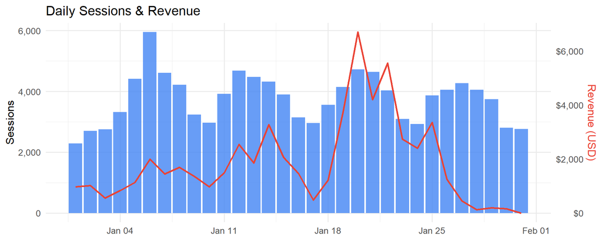

````markdown
```{r}
#| label: plot-daily
#| fig-width: 10
#| fig-height: 4
#| eval: true

library(scales)

ggplot(daily, aes(x = event_date)) +
  geom_col(aes(y = sessions), fill = "#4285F4", alpha = 0.8) +
  geom_line(
    aes(y = revenue * max(sessions) / max(revenue)),
    color = "#EA4335",
    linewidth = 1
  ) +
  scale_y_continuous(
    name = "Sessions",
    labels = comma,
    sec.axis = sec_axis(
      ~ . * max(daily$revenue) / max(daily$sessions),
      name = "Revenue (USD)",
      labels = dollar
    )
  ) +
  scale_x_date(date_labels = "%b %d", date_breaks = "1 week") +
  labs(title = "Daily Sessions & Revenue", x = NULL) +
  theme_minimal(base_size = 13) +
  theme(axis.title.y.right = element_text(color = "#EA4335"))
```
````

## 4b. Channel performance

````markdown
```{r}
#| label: channel-performance

channels <- dbGetQuery(
  duck,
  "
  WITH sessions AS (
    SELECT
      source,
      medium,
      user_pseudo_id || CAST(session_id AS VARCHAR) AS session_key
    FROM ga4
    WHERE event_name = 'session_start'
  ),
  purchases AS (
    SELECT
      source,
      medium,
      COUNT(DISTINCT transaction_id) AS transactions,
      SUM(revenue)                   AS revenue
    FROM ga4
    WHERE event_name = 'purchase'
    GROUP BY source, medium
  )
  SELECT
    s.source,
    s.medium,
    COUNT(DISTINCT s.session_key)         AS sessions,
    COALESCE(p.transactions, 0)           AS transactions,
    ROUND(COALESCE(p.revenue, 0), 2)      AS revenue,
    ROUND(100.0 * COALESCE(p.transactions, 0)
          / NULLIF(COUNT(DISTINCT s.session_key), 0), 2) AS cvr_pct
  FROM sessions s
  LEFT JOIN purchases p USING (source, medium)
  GROUP BY s.source, s.medium, p.transactions, p.revenue
  ORDER BY sessions DESC
  LIMIT 20
"
)

channels
```
````

```
                           source         medium sessions transactions revenue
1                          google        organic    37177          246   16032
2                        (direct)         (none)    27206          192   12284
3                         <Other>        <Other>    17580           99    5970
4                         <Other>       referral    11116           86    6125
5 shop.googlemerchandisestore.com       referral     8643          119    8028
6                  (data deleted) (data deleted)     6003          108    6152
7                          google            cpc     5215           33    1839
8                         <Other>        organic     3488           18     908
9                         <Other> (data deleted)       86            1      12
  cvr_pct
1    0.66
2    0.71
3    0.56
4    0.77
5    1.38
6    1.80
7    0.63
8    0.52
9    1.16
```

## 4c. Funnel analysis

````markdown
```{r}
#| label: funnel

all_counts <- dbGetQuery(
  duck,
  "
  SELECT
    event_name,
    COUNT(DISTINCT user_pseudo_id) AS users
  FROM ga4
  GROUP BY event_name
"
)

funnel <- all_counts |>
  filter(
    event_name %in%
      c(
        "session_start",
        "page_view",
        "view_item",
        "add_to_cart",
        "purchase"
      )
  ) |>
  mutate(
    event_name = factor(
      event_name,
      levels = c(
        "session_start",
        "page_view",
        "view_item",
        "add_to_cart",
        "purchase"
      )
    ),
    step_pct = round(100 * users / max(users), 1)
  ) |>
  arrange(event_name)

funnel
```
````

```
     event_name users step_pct
1 session_start 93552     98.9
2     page_view 94630    100.0
3     view_item 19629     20.7
4   add_to_cart  3832      4.0
5      purchase  1069      1.1
```

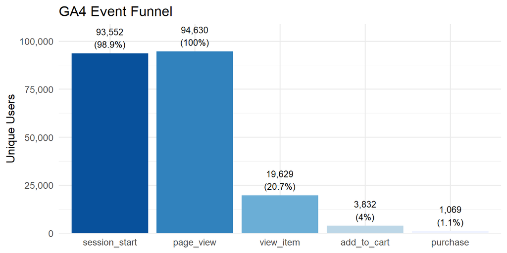

````markdown
```{r}
#| label: plot-funnel
#| fig-width: 8
#| fig-height: 4

ggplot(funnel, aes(x = event_name, y = users, fill = event_name)) +
  geom_col(show.legend = FALSE) +
  geom_text(
    aes(label = glue("{comma(users)}\n({step_pct}%)")),
    vjust = -0.3,
    size = 3.5
  ) +
  scale_y_continuous(labels = comma, expand = expansion(mult = c(0, 0.15))) +
  scale_fill_brewer(palette = "Blues", direction = -1) +
  labs(title = "GA4 Event Funnel", x = NULL, y = "Unique Users") +
  theme_minimal(base_size = 13)
```
````

## 4d. Device breakdown

````markdown
```{r}
#| label: device-breakdown

devices <- dbGetQuery(
  duck,
  "
  SELECT
    device_category,
    COUNT(DISTINCT user_pseudo_id || CAST(session_id AS VARCHAR)) AS sessions,
    ROUND(SUM(COALESCE(revenue,0)), 2)  AS revenue
  FROM ga4
  GROUP BY device_category
  ORDER BY sessions DESC
"
)

devices
```
````

```
  device_category sessions revenue
1         desktop    68618   31774
2          mobile    47061   24231
3          tablet     2639    1345
```

# 5. Using dplyr on Arrow (alternative to raw SQL)

````markdown
```{r}
#| label: dplyr-on-arrow

# dplyr on Arrow — lazy evaluation, no full materialisation until collect()
top_countries <- ga4_arrow |>
  as_tibble() |> # convert Arrow Table to a tibble
  filter(event_name == "purchase") |>
  group_by(country) |>
  summarise(
    transactions = n_distinct(transaction_id),
    revenue = sum(revenue, na.rm = TRUE),
    .groups = "drop"
  ) |>
  arrange(desc(revenue)) |>
  slice_head(n = 10)

top_countries
```
````

```
# A tibble: 10 × 3
   country        transactions revenue
   <chr>                 <int>   <dbl>
 1 United States           377   22818
 2 Canada                   82    6347
 3 India                    55    4258
 4 United Kingdom           32    2213
 5 Spain                    33    1989
 6 France                   23    1604
 7 Taiwan                   22    1445
 8 China                    23    1015
 9 Japan                    17    1011
10 Brazil                   13     900
```

# 6. Save Results to Parquet (for later reuse)

````markdown
```{r}
#| label: save-parquet
#| eval: false

# Write Arrow Table to Parquet — compressed, fast to re-read
arrow::write_parquet(
  ga4_arrow,
  "data/ga4_export.parquet",
  compression = "snappy"
)

# Later: read back without touching BigQuery at all
ga4_from_parquet <- arrow::read_parquet("data/ga4_export.parquet")

# Or query it directly from DuckDB
dbExecute(
  duck,
  "
  CREATE VIEW ga4_parquet AS
  SELECT * FROM read_parquet('data/ga4_export.parquet')
"
)
```
````

# 7. Cleanup

````markdown
```{r}
#| label: cleanup

# Always disconnect DuckDB when done
dbDisconnect(duck, shutdown = TRUE)
```
````

# Workflow Summary

[output not shown]

> **Positron tip:** Use the Variables pane to inspect Arrow Tables and DuckDB query results inline. The integrated terminal lets you render this document with `quarto render ga4_bigquery_analysis.qmd`.